# Fitting a simple slab model

In order to show one of the simplest analyses that `easyreflectometry` can perform, we will use the [great example from the *refnx* documentation](https://refnx.readthedocs.io/en/latest/getting_started.rst#Fitting-a-neutron-reflectometry-dataset). This involves the analysis of a single neutron reflectometry dataset from a hydrated polymer film system. Before we start on any analysis, we will import the necessary packages and functions.

First configure matplotlib to place figures in notebook and import needed modules. Note that the plot function needs installation of `plopp` seperately or installation of `easyreflectometry[dev]`

```python
%matplotlib inline
```

%matplotlib inline

```python
import matplotlib.pyplot as plt
import pooch
import refl1d
import refnx

import easyreflectometry
from easyreflectometry.calculators import CalculatorFactory
from easyreflectometry.data import load
from easyreflectometry.fitting import MultiFitter
from easyreflectometry.model import Model
from easyreflectometry.model import PercentageFwhm
from easyreflectometry.plot import plot
from easyreflectometry.sample import Layer
from easyreflectometry.sample import Material
from easyreflectometry.sample import Multilayer
from easyreflectometry.sample import Sample
```

import matplotlib.pyplot as plt import pooch import refl1d import refnx import easyreflectometry from easyreflectometry.calculators import CalculatorFactory from easyreflectometry.data import load from easyreflectometry.fitting import MultiFitter from easyreflectometry.model import Model from easyreflectometry.model import PercentageFwhm from easyreflectometry.plot import plot from easyreflectometry.sample import Layer from easyreflectometry.sample import Material from easyreflectometry.sample import Multilayer from easyreflectometry.sample import Sample

One of benefits of using a Jupyter Notebook for our analysis is improved reproducibility, to ensure this, below we share the version of the software packages being used.

```python
print(f'easyreflectometry: {easyreflectometry.__version__}')
print(f'refnx: {refnx.__version__}')
print(f'refl1d: {refl1d.__version__}')
```

print(f'easyreflectometry: {easyreflectometry.__version__}') print(f'refnx: {refnx.__version__}') print(f'refl1d: {refl1d.__version__}')

```
easyreflectometry: 999.0.0
refnx: 0.1.63
refl1d: 1.0.1
```

## Reading in experimental data

`easyreflectometry` has support for the `.ort` file format, a [standard file format for reduced reflectivity data developed by the Open Reflectometry Standards Organisation](https://www.reflectometry.org/working_groups/file_formats/). To load in a dataset, we use the `load` function. We use `pooch` to fetch the file from the repository.

```python
file_path = pooch.retrieve(
    # Fetch test data from the easyscience/reflectometry data repository
    url='https://raw.githubusercontent.com/easyscience/reflectometry/master/data/example.ort',
    known_hash='82d0c95c069092279a799a8131ad3710335f601d9f1080754b387f42e407dfab',
)
data = load(file_path)
```

file_path = pooch.retrieve( # Fetch test data from the easyscience/reflectometry data repository url='https://raw.githubusercontent.com/easyscience/reflectometry/master/data/example.ort', known_hash='82d0c95c069092279a799a8131ad3710335f601d9f1080754b387f42e407dfab', ) data = load(file_path)

The function about will load the file into a [*scipp* Dataset](https://scipp.github.io/user-guide/data-structures.html#Dataset) object. This offers some nice visualisations of the data, including the HTML view.

```python
data
```

data

scipp.DataGroup

()

- data

  dict

  ()

  {'R_0': <scipp.Variable> (Qz_0: 408) float64 <no unit> [0.709581, 0.8...

- coords

  dict

  ()

  {'Qz_0': <scipp.Variable> (Qz_0: 408) float64 [1/Å] [0.00806022, 0...

- attrs

  dict

  ()

  {'R_0': {'orso_header': <scipp.Variable> () PyObject <no unit> {'data_...

`easyreflectometry` also includes a custom plotting function for the data.

```python
plot(data)
```

plot(data)

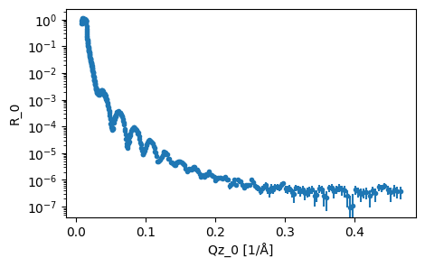

## Building our model

Now that we have read in the experimental data that we want to analyse, it is necessary that we construct some model that describes what we **think** the system looks like. The construction of this models is discussed in detail in the [model-dependent analysis](https://www.reflectometry.org/isis_school/2_model_dependent_analysis/what_is_model_dependent_analysis.html) and [reflectometry slab models](https://www.reflectometry.org/isis_school/3_reflectometry_slab_models/the_slab_model.html) sections of the ISIS Virtual Reflectometry Training Course on [neutron reflectometry fitting](https://www.reflectometry.org/isis_school/intro.html).

The system that we are investigating consists of four layers (with the top and bottom as semi-finite super- and sub-phases). The super-phase (where the neutrons are incident first) is a silicon (Si) wafer and as a process of the sample preparation there is anticipated to by a layer of silicon dioxide (SiO<sub>2</sub>) on this material. Then a polymer film has been attached to the silicon dioxide by some chemical method and this polymer film is solvated in a heavy water (D<sub>2</sub>O) which also makes up the sub-phase of the system. This is shown pictorially below, as a slab model.

[figure not shown]

A slab model description of the polymer film system (note that the layers are **not** to scale), showing the four layers of silicon, silicon dioxide, the polymer film and the heavy water subphase.

In order to constuct this model in `EasyReflecotmetry`, first we must construct objects for each of the materials that will compose the layers. These objects should be of type `Material`, when constructed `from_pars` the arguments are the real and imaginary components of the scattering length density (in units of 10<sup>-6</sup>Å<sup>-2</sup>) and some name for the material.

```python
si = Material(sld=2.07, isld=0, name='Si')
sio2 = Material(sld=3.47, isld=0, name='SiO2')
film = Material(sld=2.0, isld=0, name='Film')
d2o = Material(sld=6.36, isld=0, name='D2O')
```

si = Material(sld=2.07, isld=0, name='Si') sio2 = Material(sld=3.47, isld=0, name='SiO2') film = Material(sld=2.0, isld=0, name='Film') d2o = Material(sld=6.36, isld=0, name='D2O')

We can investigate the properties of one of these objects as follows.

```python
film
```

film

```
Film:
  sld: 2.000e-6 1/Å^2
  isld: 0.000e-6 1/Å^2
```

Next we will produce layers from each of these materials, of type `Layer`. The `from_pars` constructor for these take the material, a thickness and a interfacial roughness (on the top of the layer). The thickness and roughness values are both in Å.

```python
si_layer = Layer(material=si, thickness=0, roughness=0, name='Si layer')
sio2_layer = Layer(material=sio2, thickness=30, roughness=3, name='SiO2 layer')
film_layer = Layer(material=film, thickness=250, roughness=3, name='Film Layer')
subphase = Layer(material=d2o, thickness=0, roughness=3, name='D2O Subphase')
```

si_layer = Layer(material=si, thickness=0, roughness=0, name='Si layer') sio2_layer = Layer(material=sio2, thickness=30, roughness=3, name='SiO2 layer') film_layer = Layer(material=film, thickness=250, roughness=3, name='Film Layer') subphase = Layer(material=d2o, thickness=0, roughness=3, name='D2O Subphase')

Again, we can probe the properties of the layer as such.

```python
film_layer
```

film_layer

```
Film Layer:
  material:
    Film:
      sld: 2.000e-6 1/Å^2
      isld: 0.000e-6 1/Å^2
  thickness: 250.000 Å
  roughness: 3.000 Å
```

Given that the silicon and silicon dioxide layer both compose the solid subphase, it can be helpful to combine these as a `Multilayer` assembly type in our code.

```python
superphase = Multilayer([si_layer, sio2_layer], name='Si/SiO2 Superphase')
```

superphase = Multilayer([si_layer, sio2_layer], name='Si/SiO2 Superphase')

These objects are then combined as a `Sample`, where the constructor takes a series of layers (or some more complex `easyreflectometry` assemblies) and, optionally, some name for the sample.

```python
sample = Sample(superphase, Multilayer(film_layer), Multilayer(subphase), name='Film Structure')
```

sample = Sample(superphase, Multilayer(film_layer), Multilayer(subphase), name='Film Structure')

This sample can be investigated from the string representation like the other objects.

```python
sample
```

sample

```
Film Structure:
- Si/SiO2 Superphase:
    Si layer/SiO2 layer:
    - Si layer:
        material:
          Si:
            sld: 2.070e-6 1/Å^2
            isld: 0.000e-6 1/Å^2
        thickness: 0.000 Å
        roughness: 0.000 Å
    - SiO2 layer:
        material:
          SiO2:
            sld: 3.470e-6 1/Å^2
            isld: 0.000e-6 1/Å^2
        thickness: 30.000 Å
        roughness: 3.000 Å
- EasyMultilayer:
    Film Layer:
    - Film Layer:
        material:
          Film:
            sld: 2.000e-6 1/Å^2
            isld: 0.000e-6 1/Å^2
        thickness: 250.000 Å
        roughness: 3.000 Å
- EasyMultilayer:
    D2O Subphase:
    - D2O Subphase:
        material:
          D2O:
            sld: 6.360e-6 1/Å^2
            isld: 0.000e-6 1/Å^2
        thickness: 0.000 Å
        roughness: 3.000 Å
```

## Constructing the model

The structure of the system under investigation is just part of the analysis story. It is also necessary to describe the instrumental parameters, namely the background level, the resolution and some option to scale the data in the *y*-axis.

Note

Currently, only constant with resolution is supported. We are working to include more complex resolution in future.

the `Model` constructor takes our smple, a scale factor, a uniform background level and a resolution function.

```python
resolution_function = PercentageFwhm(0.02)
model = Model(sample=sample, scale=1, background=1e-6, resolution_function=resolution_function, name='Film Model')
```

resolution_function = PercentageFwhm(0.02) model = Model(sample=sample, scale=1, background=1e-6, resolution_function=resolution_function, name='Film Model')

From this object, we can investigate all of the parameters of our model.

```python
model
```

model

```
Film Model:
  scale: 1.0
  background: 1.0e-06
  resolution: 0.02 %
  color: '#0173B2'
  sample:
    Film Structure:
    - Si/SiO2 Superphase:
        Si layer/SiO2 layer:
        - Si layer:
            material:
              Si:
                sld: 2.070e-6 1/Å^2
                isld: 0.000e-6 1/Å^2
            thickness: 0.000 Å
            roughness: 0.000 Å
        - SiO2 layer:
            material:
              SiO2:
                sld: 3.470e-6 1/Å^2
                isld: 0.000e-6 1/Å^2
            thickness: 30.000 Å
            roughness: 3.000 Å
    - EasyMultilayer:
        Film Layer:
        - Film Layer:
            material:
              Film:
                sld: 2.000e-6 1/Å^2
                isld: 0.000e-6 1/Å^2
            thickness: 250.000 Å
            roughness: 3.000 Å
    - EasyMultilayer:
        D2O Subphase:
        - D2O Subphase:
            material:
              D2O:
                sld: 6.360e-6 1/Å^2
                isld: 0.000e-6 1/Å^2
            thickness: 0.000 Å
            roughness: 3.000 Å
```

## Setting varying parameters

Now that the model is fully constructed, we can select the parameters in our model that should be varied. Below we set the thickness of the SiO<sub>2</sub> and film layers to vary along with the real scattering length density of the film and all of the roughnesses.

```python
# Thicknesses
sio2_layer.thickness.min = 15
sio2_layer.thickness.max = 50
film_layer.thickness.min = 200
film_layer.thickness.max = 300
# Roughnesses
sio2_layer.roughness.min = 1
sio2_layer.roughness.max = 15
film_layer.roughness.min = 1
film_layer.roughness.max = 15
subphase.roughness.min = 1
subphase.roughness.max = 15
# Scattering length density
film_layer.material.sld.min = 0.1
film_layer.material.sld.max = 3
```

# Thicknesses sio2_layer.thickness.min = 15 sio2_layer.thickness.max = 50 film_layer.thickness.min = 200 film_layer.thickness.max = 300 # Roughnesses sio2_layer.roughness.min = 1 sio2_layer.roughness.max = 15 film_layer.roughness.min = 1 film_layer.roughness.max = 15 subphase.roughness.min = 1 subphase.roughness.max = 15 # Scattering length density film_layer.material.sld.min = 0.1 film_layer.material.sld.max = 3

In addition to these variables of the structure, we will also vary the background level and scale factor.

```python
# Background
model.background.min = 1e-8
model.background.max = 1e-5
# Scale
model.scale.min = 0.5
model.scale.max = 1.5
```

# Background model.background.min = 1e-8 model.background.max = 1e-5 # Scale model.scale.min = 0.5 model.scale.max = 1.5

## Choosing our calculation engine

The `easyreflectometry` package enables the calculation of the reflectometry profile using either [*refnx*](https://refnx.readthedocs.io/) or [*Refl1D*](https://refl1d.readthedocs.io/en/latest/). We will first run the fit with the current default, *refnx*, and then rebuild the same starting model with *Refl1D* to compare the results. The calculator must be created and associated with the model that we are to fit.

```python
interface = CalculatorFactory()
model.interface = interface
```

interface = CalculatorFactory() model.interface = interface

We can check the calculation engine currently in use as follows.

```python
print(interface.current_interface.name)
```

print(interface.current_interface.name)

```
refnx
```

## Performing an optimisation

The optimisation of our model is achieved with a `MultiFitter`, which takes our model.

```python
fitter = MultiFitter(model)
```

fitter = MultiFitter(model)

```
CollectionBase is deprecated and will be removed in a future version. Please migrate to ModelBase or EasyList.
```

To actually perform the optimisation, we must pass our `data` object created from the experimental data. This will return a new `sc.Dataset` with the result of out analysis, and the model will be updated in place.

```python
analysed_refnx = fitter.fit(data)
analysed = analysed_refnx
```

analysed_refnx = fitter.fit(data) analysed = analysed_refnx

```
Invalid Input Parameters. I.e. more variables than data points given, tolerance < 0.0, or no data provided. Could not estimate error-bars.
```

```python
analysed
```

analysed

scipp.DataGroup

(Qz_0: 408, z_0: 500)

- data

  dict

  ()

  {'R_0': <scipp.Variable> (Qz_0: 408) float64 <no unit> [0.709581, 0.8...

- coords

  dict

  ()

  {'Qz_0': <scipp.Variable> (Qz_0: 408) float64 [1/Å] [0.00806022, 0...

- attrs

  dict

  ()

  {'R_0': {'orso_header': <scipp.Variable> () PyObject <no unit> {'data_...

- R_0_model

  scipp

  Variable

  (Qz_0: 408)

  float64

  𝟙

  1.000, 1.000, ..., 1.009e-06, 1.017e-06

- SLD_0

  scipp

  Variable

  (z_0: 500)

  float64

  1/Å^2

  2.070e-06, 2.070e-06, ..., 6.360e-06, 6.360e-06

- objective_chi2

  float

  ()

  81070.00537439948

- objective_reduced_chi

  float

  ()

  198.70099356470462

- classical_chi2

  float

  ()

  81070.00537439948

- classical_reduced_chi

  float

  ()

  198.70099356470462

- reduced_chi

  float

  ()

  198.70099356470462

- success

  bool

  ()

  False

The same `plot` function that was used on the raw data can be used for this `analysed` object and will show the best fit simulated data and the associated scattering length density profile.

```python
plot(analysed)
```

plot(analysed)

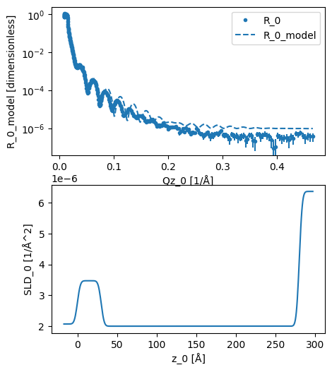

```python
model
```

model

```
Film Model:
  scale: 1.0
  background: 1.0e-06
  resolution: 0.02 %
  color: '#0173B2'
  sample:
    Film Structure:
    - Si/SiO2 Superphase:
        Si layer/SiO2 layer:
        - Si layer:
            material:
              Si:
                sld: 2.070e-6 1/Å^2
                isld: 0.000e-6 1/Å^2
            thickness: 0.000 Å
            roughness: 0.000 Å
        - SiO2 layer:
            material:
              SiO2:
                sld: 3.470e-6 1/Å^2
                isld: 0.000e-6 1/Å^2
            thickness: 30.000 Å
            roughness: 3.000 Å
    - EasyMultilayer:
        Film Layer:
        - Film Layer:
            material:
              Film:
                sld: 2.000e-6 1/Å^2
                isld: 0.000e-6 1/Å^2
            thickness: 250.000 Å
            roughness: 3.000 Å
    - EasyMultilayer:
        D2O Subphase:
        - D2O Subphase:
            material:
              D2O:
                sld: 6.360e-6 1/Å^2
                isld: 0.000e-6 1/Å^2
            thickness: 0.000 Å
            roughness: 3.000 Å
```

## Repeating the optimisation with Refl1D

To compare backends fairly, we rebuild the same initial model and then switch the calculator to `refl1d`. This ensures that the second optimisation starts from the same parameter guesses rather than from the already-optimised `refnx` result.

```python
print(f'refl1d: {refl1d.__version__}')

si_refl1d = Material(sld=2.07, isld=0, name='Si')
sio2_refl1d = Material(sld=3.47, isld=0, name='SiO2')
film_refl1d = Material(sld=2.0, isld=0, name='Film')
d2o_refl1d = Material(sld=6.36, isld=0, name='D2O')

si_layer_refl1d = Layer(material=si_refl1d, thickness=0, roughness=0, name='Si layer')
sio2_layer_refl1d = Layer(material=sio2_refl1d, thickness=30, roughness=3, name='SiO2 layer')
film_layer_refl1d = Layer(material=film_refl1d, thickness=250, roughness=3, name='Film Layer')
subphase_refl1d = Layer(material=d2o_refl1d, thickness=0, roughness=3, name='D2O Subphase')

superphase_refl1d = Multilayer([si_layer_refl1d, sio2_layer_refl1d], name='Si/SiO2 Superphase')
sample_refl1d = Sample(superphase_refl1d, Multilayer(film_layer_refl1d), Multilayer(subphase_refl1d), name='Film Structure')

resolution_function_refl1d = PercentageFwhm(0.02)
model_refl1d = Model(
    sample=sample_refl1d, scale=1, background=1e-6, resolution_function=resolution_function_refl1d, name='Film Model (Refl1D)'
)

sio2_layer_refl1d.thickness.min = 15
sio2_layer_refl1d.thickness.max = 50
film_layer_refl1d.thickness.min = 200
film_layer_refl1d.thickness.max = 300
sio2_layer_refl1d.roughness.min = 1
sio2_layer_refl1d.roughness.max = 15
film_layer_refl1d.roughness.min = 1
film_layer_refl1d.roughness.max = 15
subphase_refl1d.roughness.min = 1
subphase_refl1d.roughness.max = 15
film_layer_refl1d.material.sld.min = 0.1
film_layer_refl1d.material.sld.max = 3
model_refl1d.background.min = 1e-8
model_refl1d.background.max = 1e-5
model_refl1d.scale.min = 0.5
model_refl1d.scale.max = 1.5

interface_refl1d = CalculatorFactory()
interface_refl1d.switch('refl1d')
model_refl1d.interface = interface_refl1d

print(interface_refl1d.current_interface.name)
```

print(f'refl1d: {refl1d.__version__}') si_refl1d = Material(sld=2.07, isld=0, name='Si') sio2_refl1d = Material(sld=3.47, isld=0, name='SiO2') film_refl1d = Material(sld=2.0, isld=0, name='Film') d2o_refl1d = Material(sld=6.36, isld=0, name='D2O') si_layer_refl1d = Layer(material=si_refl1d, thickness=0, roughness=0, name='Si layer') sio2_layer_refl1d = Layer(material=sio2_refl1d, thickness=30, roughness=3, name='SiO2 layer') film_layer_refl1d = Layer(material=film_refl1d, thickness=250, roughness=3, name='Film Layer') subphase_refl1d = Layer(material=d2o_refl1d, thickness=0, roughness=3, name='D2O Subphase') superphase_refl1d = Multilayer([si_layer_refl1d, sio2_layer_refl1d], name='Si/SiO2 Superphase') sample_refl1d = Sample(superphase_refl1d, Multilayer(film_layer_refl1d), Multilayer(subphase_refl1d), name='Film Structure') resolution_function_refl1d = PercentageFwhm(0.02) model_refl1d = Model( sample=sample_refl1d, scale=1, background=1e-6, resolution_function=resolution_function_refl1d, name='Film Model (Refl1D)' ) sio2_layer_refl1d.thickness.min = 15 sio2_layer_refl1d.thickness.max = 50 film_layer_refl1d.thickness.min = 200 film_layer_refl1d.thickness.max = 300 sio2_layer_refl1d.roughness.min = 1 sio2_layer_refl1d.roughness.max = 15 film_layer_refl1d.roughness.min = 1 film_layer_refl1d.roughness.max = 15 subphase_refl1d.roughness.min = 1 subphase_refl1d.roughness.max = 15 film_layer_refl1d.material.sld.min = 0.1 film_layer_refl1d.material.sld.max = 3 model_refl1d.background.min = 1e-8 model_refl1d.background.max = 1e-5 model_refl1d.scale.min = 0.5 model_refl1d.scale.max = 1.5 interface_refl1d = CalculatorFactory() interface_refl1d.switch('refl1d') model_refl1d.interface = interface_refl1d print(interface_refl1d.current_interface.name)

```
refl1d: 1.0.1
refl1d
```

We can now fit the same dataset with `refl1d` and compare the fitted curve and reduced chi-squared with the earlier `refnx` result.

```python
fitter_refl1d = MultiFitter(model_refl1d)
analysed_refl1d = fitter_refl1d.fit(data)

print(f'refnx reduced chi: {analysed_refnx["reduced_chi"]:.4f}')
print(f'refl1d reduced chi: {analysed_refl1d["reduced_chi"]:.4f}')

qz = data['coords']['Qz_0'].values
reflectivity = data['data']['R_0'].values
uncertainty = data['data']['R_0'].variances ** 0.5

plt.figure(figsize=(8, 5))
plt.errorbar(qz, reflectivity, yerr=uncertainty, fmt='o', markersize=3, color='black', alpha=0.6, label='Data')
plt.plot(qz, analysed_refnx['R_0_model'].values, linewidth=2.5, label='refnx fit')
plt.plot(qz, analysed_refl1d['R_0_model'].values, linewidth=2.5, label='refl1d fit')
plt.yscale('log')
plt.xlabel(r'$Q_z$ (1/Å)')
plt.ylabel('Reflectivity')
plt.grid(True, which='both', alpha=0.25)
plt.legend()
plt.show()

print('refnx model')
print(model)
print()
print('refl1d model')
print(model_refl1d)
```

fitter_refl1d = MultiFitter(model_refl1d) analysed_refl1d = fitter_refl1d.fit(data) print(f'refnx reduced chi: {analysed_refnx["reduced_chi"]:.4f}') print(f'refl1d reduced chi: {analysed_refl1d["reduced_chi"]:.4f}') qz = data['coords']['Qz_0'].values reflectivity = data['data']['R_0'].values uncertainty = data['data']['R_0'].variances ** 0.5 plt.figure(figsize=(8, 5)) plt.errorbar(qz, reflectivity, yerr=uncertainty, fmt='o', markersize=3, color='black', alpha=0.6, label='Data') plt.plot(qz, analysed_refnx['R_0_model'].values, linewidth=2.5, label='refnx fit') plt.plot(qz, analysed_refl1d['R_0_model'].values, linewidth=2.5, label='refl1d fit') plt.yscale('log') plt.xlabel(r'$Q_z$ (1/Å)') plt.ylabel('Reflectivity') plt.grid(True, which='both', alpha=0.25) plt.legend() plt.show() print('refnx model') print(model) print() print('refl1d model') print(model_refl1d)

```
CollectionBase is deprecated and will be removed in a future version. Please migrate to ModelBase or EasyList.
```

```
Invalid Input Parameters. I.e. more variables than data points given, tolerance < 0.0, or no data provided. Could not estimate error-bars.
```

```
refnx reduced chi: 198.7010
refl1d reduced chi: 198.6718
```

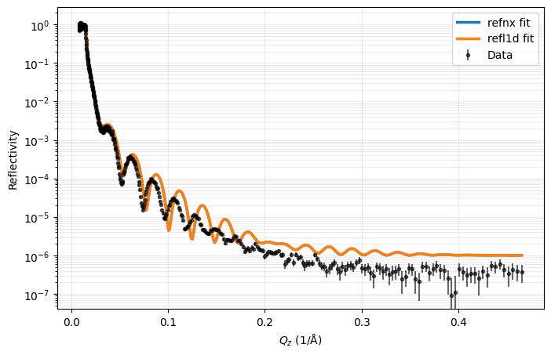

```
refnx model
Film Model:
  scale: 1.0
  background: 1.0e-06
  resolution: 0.02 %
  color: '#0173B2'
  sample:
    Film Structure:
    - Si/SiO2 Superphase:
        Si layer/SiO2 layer:
        - Si layer:
            material:
              Si:
                sld: 2.070e-6 1/Å^2
                isld: 0.000e-6 1/Å^2
            thickness: 0.000 Å
            roughness: 0.000 Å
        - SiO2 layer:
            material:
              SiO2:
                sld: 3.470e-6 1/Å^2
                isld: 0.000e-6 1/Å^2
            thickness: 30.000 Å
            roughness: 3.000 Å
    - EasyMultilayer:
        Film Layer:
        - Film Layer:
            material:
              Film:
                sld: 2.000e-6 1/Å^2
                isld: 0.000e-6 1/Å^2
            thickness: 250.000 Å
            roughness: 3.000 Å
    - EasyMultilayer:
        D2O Subphase:
        - D2O Subphase:
            material:
              D2O:
                sld: 6.360e-6 1/Å^2
                isld: 0.000e-6 1/Å^2
```

[output cut: 31 more lines]

```
            material:
              Film:
                sld: 2.000e-6 1/Å^2
                isld: 0.000e-6 1/Å^2
            thickness: 250.000 Å
            roughness: 3.000 Å
    - EasyMultilayer:
        D2O Subphase:
        - D2O Subphase:
            material:
              D2O:
                sld: 6.360e-6 1/Å^2
                isld: 0.000e-6 1/Å^2
            thickness: 0.000 Å
            roughness: 3.000 Å
```